# NYC Electrcity Load Forecast - ML Model Comparison

### Summary

- Predicting demand (load forecasting) is a fundamental activity for grid operators and electricity market participants. Accurate load forecasts help in planning and scheduling generation and transmission resources effectively.
- This project evaluates the performance of 24-hour electricity load forecasting machine learning (ML) models for NYC using weather variables.
- (for detailed EDA and data preprocessing see NYC_EDA_preprocessing.html)

#### Aim:

- Build ML models capable of 24-hour ahead load forecasting with potential real-world application.
- Choose variables for the models which would likely be available to forecasters 24-hours in advance i.e. given the accuracy of 24-hour ahead weather forecasts, weather forecast variables are considered acceptable.
- Evaluate ML model performance.

#### Models:

- Baseline: decision tree (DT), linear regression (LR)
- Advanced models: linear regression (LR) and XGBoost with tree-based boosting (xgboost)
- (Models were chosen according to literature review of most popular ML models in similar projects)

#### Data:

- Hourly, 2016 - 2019
- Independent variables:
  - Weather = dry-bulb temperature, precipitation, humidity, pressure
  - Time/date = month, hour
  - Engineered Features:
    - 24hr lag = all weather features, MWh
  - Weekday/weekend
- Dependent variable:
  - Electricity demand (MWh)

#### Methodology:

1. Split data into training and test sets and normalise values (train = 2016-2018, test = 2019)
2. Build baseline models
3. Build advanced models incl. polynomials and hyper/parameter tuning
4. Evaluate performance

#### Performance Evaluation Metrics:

- Mean absolute error (MAE)
- Mean squared error (MSE)
- Root mean squared error (RMSE)
- R-squared (R2)

#### Results: Model evaluation

- Key results:
  - DT_base performs worst across all metrics on train and test sets
  - Advanced LR model achieves better results than base LR without reducing generalisability on the test data
  - The DT and both LR models maintain similar results on train and test sets suggesting robust performance on new, unseen data. They have therefore avoided overfitting
  - Despite the reputation of xgbtree robustness against overfitting and the use of CV for model parameters, it appears the model is overfit due to a the compartively large difference between train and test metrics
  - However, overall the XGBoost model achieves the best overall metrics

#### 1. Split Dataset and Normalise

- Train = 2016, 2017, 2018
- Test = 2019

```r
#split data into train and test
train <- master %>%
  filter(year %in% c(2016, 2017, 2018)) %>%
  select(-year, -day)
test <- master %>%
  filter(year == 2019) %>%
  select(-year, -day)
#scale results
numeric_columns <- sapply(train, is.numeric)
data_sets <- list(train, test)
for (i in seq_along(data_sets)) {
  data_sets[[i]][, numeric_columns] <- scale(data_sets[[i]][, numeric_columns])
}
train <- data_sets[[1]]
test <- data_sets[[2]]
```

#### 2. Baseline Model Building

##### 2.1 Decision Tree & Linear regression

- These metrics will be compared against advanced model performance

```r
# baseline decision tree
baseline_dt <- rpart(MWh ~ ., data = train,
            minsplit = 10,
            minbucket = 2,
            cp = 0.01)
# baseline Linear Regression
baseline_lr <- lm(MWh ~ ., data = train)
# predictions
train_predictions_base <- train %>% select(MWh)
models <- list(baseline_dt, baseline_lr)
for (i in 1:length(models)) {
  predictions <- as.data.frame(predict(models[[i]], newdata = train))
  model_name <- c("DT", "LR")[i]
  names(predictions)[1] <- paste(model_name,"train",sep = "_")
  train_predictions_base <- cbind(train_predictions_base, predictions)
}

# extract true values and model estimates
true_values <- train_predictions_base[, 1]
model_estimates <- train_predictions_base[, 2:3]
# Create data frame to store results
evaluation_results <- data.frame(Model = character(0), MAE = numeric(0), MSE = numeric(0), RMSE = numeric(0), R2 = numeric(0))
model_names <- c("DT_base", "LR_base")
# loop and calculate evaluation train metrics
for (i in 1:length(model_names)) {
  model_name <- model_names[i]
  predictions <- model_estimates[, i]
  mae <- mean(abs(predictions - true_values))
  mse <- mean((predictions - true_values)^2)
  rmse <- sqrt(mse)
  r_squared <- 1 - (sum((predictions - true_values)^2) / sum((mean(true_values) - true_values)^2))
  result_row <- data.frame(Model = model_name, MAE = mae, MSE = mse, RMSE = rmse, R2 = r_squared)
  evaluation_results <- rbind(evaluation_results, result_row)
}
evaluation_results <- pivot_longer(evaluation_results, cols = -Model, names_to = "column_name", values_to = "value")
evaluation_results_train <- pivot_wider(evaluation_results, names_from = Model, values_from = value)

## calculate test metrics
# predictions
test_predictions_base <- test %>% select(MWh)
for (i in 1:length(models)) {
  predictions <- as.data.frame(predict(models[[i]], newdata = test))
  model_name <- c("DT", "LR")[i]
  names(predictions)[1] <- paste(model_name,"train",sep = "_")
  test_predictions_base <- cbind(test_predictions_base, predictions)
}

# extract true values and model estimates
true_values <- test_predictions_base[, 1]
model_estimates <- test_predictions_base[, 2:3]
# Create data frame to store results
base_results_test <- data.frame(Model = character(0), MAE = numeric(0), MSE = numeric(0), RMSE = numeric(0), R2 = numeric(0))
model_names <- c("DT_base", "LR_base")
# loop and calculate evaluation metrics
for (i in 1:length(model_names)) {
  model_name <- model_names[i]
  predictions <- model_estimates[, i]
  mae <- mean(abs(predictions - true_values))
  mse <- mean((predictions - true_values)^2)
  rmse <- sqrt(mse)
  r_squared <- 1 - (sum((predictions - true_values)^2) / sum((mean(true_values) - true_values)^2))
  result_row <- data.frame(Model = model_name, MAE = mae, MSE = mse, RMSE = rmse, R2 = r_squared)
  base_results_test <- rbind(base_results_test, result_row)
}
base_results_test <- pivot_longer(base_results_test, cols = -Model, names_to = "column_name", values_to = "value")
base_results_test <- pivot_wider(base_results_test, names_from = Model, values_from = value)
print(evaluation_results_train)
```

```
## # A tibble: 4 × 3
##   column_name DT_base LR_base
##   <chr>         <dbl>   <dbl>
## 1 MAE           0.325   0.262
## 2 MSE           0.191   0.124
## 3 RMSE          0.437   0.353
## 4 R2            0.809   0.876
```

```r
print(base_results_test)
```

```
## # A tibble: 4 × 3
##   column_name DT_base LR_base
##   <chr>         <dbl>   <dbl>
## 1 MAE           0.321   0.266
## 2 MSE           0.183   0.124
## 3 RMSE          0.427   0.352
## 4 R2            0.817   0.876
```

#### 3. Advanced Models

##### 3.1 Advanced Linear Regression

- Polynomial - add polynomials to 5th degree for dry bulb temperature as EDA plot revealed non-linear relationship
- Review MSE for polynomials, select appropriate polynomial feature
- Build advanced LR model

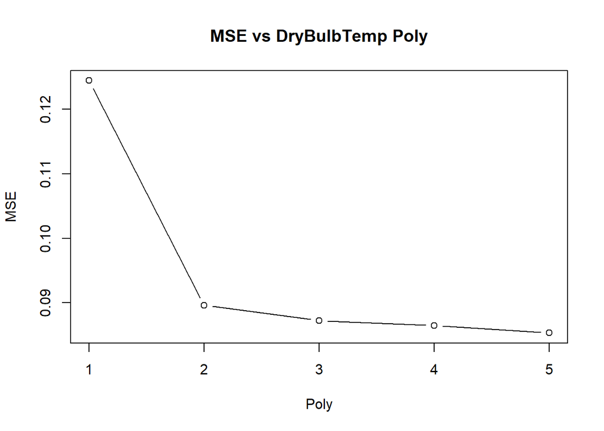

```r
# add polynomial for drybulb temperature
column_name <- "DryBulbTemperature"
train_poly_df <- as.data.frame(poly(train[, column_name], 5, raw = TRUE))
colnames(train_poly_df) <- paste(column_name, 1:5, sep="_")
# test
test_poly_df <- as.data.frame(poly(test[, column_name], 5, raw = TRUE))
colnames(test_poly_df) <- paste(column_name, 1:5, sep="_")
# combine the original train & test and the polynomial features
train_poly <- cbind(train, train_poly_df)
test_poly <- cbind(test, test_poly_df)

# dependent variable
response_variable <- "MWh"
exclude_columns <- c(response_variable)
drybulb_columns <- grep("^DryBulbTemperature_", names(train_poly), value = TRUE)
independent_variables <- setdiff(names(train_poly), c(exclude_columns, drybulb_columns))
# list to store results
lm_models <- list()
mse_values <- list()
# loop over different polynomial degrees
for (degree in 1:5) {
  formula <- as.formula(paste(response_variable, "~", paste(c(paste("DryBulbTemperature", 1:degree, sep = "_"), independent_variables), collapse = "+")))
  lm_model <- lm(formula, data = train_poly)
  lm_models[[as.character(degree)]] <- lm_model
  predictions <- predict(lm_model, newdata = train_poly)
  residuals <- residuals(lm_model)
  mse <- mean(residuals^2)
  mse_values[[as.character(degree)]] <- mse
}
# plot mse values for different poly degrees
plot(1:length(lm_models), mse_values, type = "b", xlab = "Poly", ylab = "MSE", main = "MSE vs DryBulbTemp Poly")
```

```r
# select 2 polynomial,  add to train
train_padd <- cbind(train, train_poly_df["DryBulbTemperature_2"])
```

- Train advanced LR model using poly 2 and save metrics

```r
# train advanced lm model
LR_advance <- lm(MWh ~ ., data = train_padd)
# predict using train set
lra_train_predict <- predict(LR_advance, newdata = train_padd)
# calculate metrics for predictions
mae_LR_advance <- mean(abs(train_padd$MWh - lra_train_predict))
mse_LR_advance <- mean((train_padd$MWh - lra_train_predict)^2)
rmse_LR_advance <- sqrt(mean((train_padd$MWh - lra_train_predict)^2))
r_sq_LR_advance <- cor(train_padd$MWh, lra_train_predict)^2
#add to evaluation_results_train
variable_names <- c("mae_LR_advance", "mse_LR_advance", "rmse_LR_advance", "r_sq_LR_advance")
for (i in seq_along(variable_names)) {
  metric_index <- match(evaluation_results_train$column_name[i], names(evaluation_results_train))
  evaluation_results_train[i, "LR_advance"] <- get(variable_names[i])
}
```

- Evaluate advanced LR model on test set data and save metrics

```r
#add poly2 to test set
test_padd <- cbind(test, test_poly_df["DryBulbTemperature_2"])
# predict using test set
lra_test_predict <- predict(LR_advance, newdata = test_padd)
# calculate metrics for predictions
mae_lr_advance_test <- mean(abs(test_padd$MWh - lra_test_predict))
mse_lr_advance_test <- mean((test_padd$MWh - lra_test_predict)^2)
rmse_lr_advance_test <- sqrt(mean((test_padd$MWh - lra_test_predict)^2))
r_sq_lr_advance_test <- cor(test_padd$MWh, lra_test_predict)^2
# create results df
eval_results_test <- data.frame(
  metrics = c("MAE", "MSE", "RMSE", "R2"),
  LR_advance_test = c(mae_lr_advance_test, mse_lr_advance_test, rmse_lr_advance_test, r_sq_lr_advance_test)
)
```

##### 3.2 Advanced XGBoost

- Build XGBoost advanced model using XGBtree and cross-validation random search to optimise parameters based on RMSE

```r
# create encoded columns
train_month <- train_padd %>% select(month)
encoded_matrix_month <- as.data.frame(model.matrix(~ 0 + ., data = train_month))
train_hour <- train_padd %>% select(hour)
encoded_matrix_hour <- as.data.frame(model.matrix(~ 0 + ., data = train_hour))
train_weekdayorweekend <- train_padd %>% select(weekdayorweekend)
encoded_matrix_weekdayorweekend <- as.data.frame(model.matrix(~ 0 + ., data = train_weekdayorweekend))
# bind encoded
train_encoded <- cbind(train_padd, encoded_matrix_month, encoded_matrix_weekdayorweekend,encoded_matrix_hour) %>% select(-month,-hour,-weekdayorweekend)
# set parameters
n_samples <- 10
param_grid <- data.frame(
  nrounds = sample(100:300, n_samples, replace = TRUE),
  max_depth = sample(3:10, n_samples, replace = TRUE),
  eta = runif(n_samples, 0.01, 0.3),
  gamma = runif(n_samples, 0, 2),
  colsample_bytree = runif(n_samples, 0.7, 0.9),
  subsample = runif(n_samples, 0.7, 0.9),
  min_child_weight = sample(1:5, n_samples, replace = TRUE)
)

# perform cross-validation with grid search
set.seed(123)
ctrl <- trainControl(method = "cv", number = 5)
# define the model
model <- train(
  x = train_encoded[, -10],
  y = train_encoded[, 10],
  method = "xgbTree",
  trControl = ctrl,
  tuneGrid = param_grid,
  metric = "RMSE"
)

# select best model and its parameters
best_model <- model$bestTune
# train model using best parameters
xgb <- xgboost(
  data = as.matrix(train_encoded[, -10]),
  label = train_encoded[, 10],
  nrounds = best_model$nrounds,
  max_depth = best_model$max_depth,
  eta = best_model$eta,
  gamma = best_model$gamma,
  colsample_bytree = best_model$colsample_bytree,
  subsample = best_model$subsample,
  min_child_weight = best_model$min_child_weight
)
# print summary
xgb_var_info <- xgb.importance(model = xgb)
#print(xgb_var_info)
```

- Evaluate XGBoost performance on training and test sets

```r
# predict using train set
train_predictions <- train_padd %>% select(MWh)
xgb_train_predictions <- predict(xgb, as.matrix(train_encoded[, -10]))
names(xgb_train_predictions)[1] <- "XGB_train"
train_predictions <- cbind(train_predictions, xgb_train_predictions)
# calculate metrics for predictions
mae_xgb_train <- mean(abs(train_predictions$MWh - xgb_train_predictions))
mse_xgb_train <- mean((train_predictions$MWh - xgb_train_predictions)^2)
rmse_xgb_train <- sqrt(mean((train_predictions$MWh - xgb_train_predictions)^2))
r_sq_xgb_train <- cor(train_predictions$MWh, xgb_train_predictions)^2
#add to evaluation_results_train
variable_names <- c("mae_xgb_train", "mse_xgb_train", "rmse_xgb_train", "r_sq_xgb_train")
for (i in seq_along(variable_names)) {
  metric_index <- match(evaluation_results_train$column_name[i], names(evaluation_results_train))
  evaluation_results_train[i, "xgb"] <- get(variable_names[i])
}

#test encoded
test_month <- test_padd %>% select(month)
encoded_matrix_month <- as.data.frame(model.matrix(~ 0 + ., data = test_month))
test_hour <- test_padd %>% select(hour)
encoded_matrix_hour <- as.data.frame(model.matrix(~ 0 + ., data = test_hour))
test_weekdayorweekend <- test_padd %>% select(weekdayorweekend)
encoded_matrix_weekdayorweekend <- as.data.frame(model.matrix(~ 0 + ., data = test_weekdayorweekend))
test_encoded <- cbind(test_padd, encoded_matrix_month, encoded_matrix_weekdayorweekend,encoded_matrix_hour) %>% select(-month,-hour,-weekdayorweekend)
# predict using test set
test_predictions <- test_padd %>% select(MWh)
xgb_test_predictions <- predict(xgb, as.matrix(test_encoded[, -10]))
names(xgb_test_predictions)[1] <- "XGB_test"
test_predictions <- cbind(test_predictions, xgb_test_predictions)
# calculate metrics for predictions
mae_xgb_test <- mean(abs(test_predictions$MWh - xgb_test_predictions))
mse_xgb_test <- mean((test_predictions$MWh - xgb_test_predictions)^2)
rmse_xgb_test <- sqrt(mean((test_predictions$MWh - xgb_test_predictions)^2))
r_sq_xgb_test <- cor(test_predictions$MWh, xgb_test_predictions)^2
#add to eval_results_test
variable_names <- c("mae_xgb_test", "mse_xgb_test", "rmse_xgb_test", "r_sq_xgb_test")
for (i in seq_along(variable_names)) {
  metric_index <- match(eval_results_test$column_name[i], names(eval_results_test))
  eval_results_test[i, "xgb"] <- get(variable_names[i])
}
```

#### 4. Evaluate Model Performance

##### 4.1 Plot results

- Compare metrics for different models on train and test sets
- Key results:
  - DT_base performs worst across all metrics on train and test sets
  - Advanced LR model achieves better results than base LR without reducing generalisability on the test data
  - The DT and both LR models maintain similar results on train and test sets suggesting robust performance on new, unseen data. They have therefore avoided overfitting
  - Despite the reputation of xgbtree robustness against overfitting and the use of CV for model parameters, it appears the model is overfit due to a the compartively large difference between train and test metrics
  - However, overall the XGBoost model achieves the best overall metrics

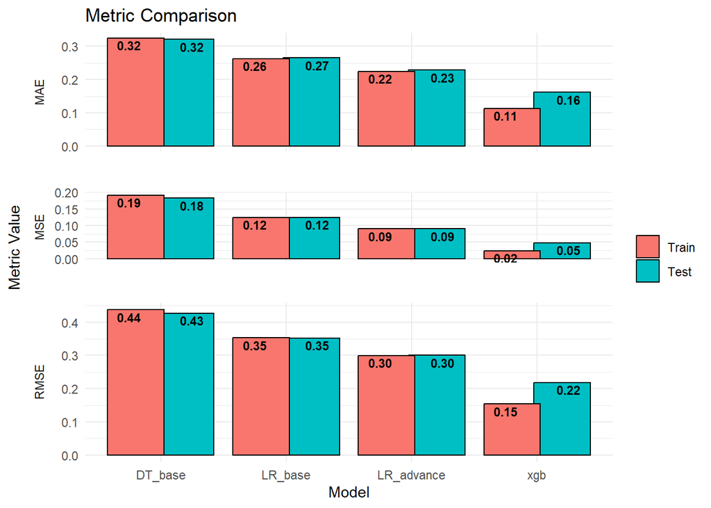

```r
# combine test results
eval_results_test <- cbind(eval_results_test, base_results_test[2:3])
colnames(eval_results_test)[colnames(eval_results_test) == "LR_advance_test"] <- "LR_advance"
colnames(evaluation_results_train)[colnames(evaluation_results_train) == "column_name"] <- "metrics"
combined_test_train <- bind_rows(
  mutate(eval_results_test, dataset = "Test"),
  mutate(evaluation_results_train, dataset = "Train")
)
column_order <- c("metrics", "DT_base", "LR_base", "LR_advance", "xgb", "dataset")
combined_test_train <- combined_test_train %>%
  select(all_of(column_order)) %>%
  filter(metrics != "R2")
# Reshape the data
combined_tt <- combined_test_train %>%
  pivot_longer(cols = c("DT_base", "LR_base", "LR_advance", "xgb"),
               names_to = "model",
               values_to = "value")
combined_tt$model <- factor(combined_tt$model, levels = c("DT_base", "LR_base", "LR_advance", "xgb"))

combined_tt$metrics <- factor(combined_tt$metrics, levels = c("MAE", "MSE", "RMSE"))

# Plotting using ggplot2 with facet_grid
error_metrics <- ggplot(combined_tt, aes(x = model, y = value, fill = factor(dataset, levels = c("Train", "Test")))) +
  geom_bar(stat = "identity", position = position_dodge(width = 0.8), color = "black") +
  geom_text(aes(label = sprintf("%0.2f", value), y = value),
            position = position_dodge(width = 1),
            vjust = 1.25,
            size = 3,
            fontface = "bold") +
  facet_grid(metrics ~ ., scales = "free_y", switch = "both", space = "free") +
  labs(title = "Metric Comparison",
       x = "Model",
       y = "Metric Value",
       fill = "") +  # Remove legend title
  theme_minimal() +
  theme(panel.spacing.y = unit(2, "lines")) +
  theme(legend.position = "right", strip.placement = "outside")

#R2
combined_test_train <- bind_rows(
  mutate(eval_results_test, dataset = "Test"),
  mutate(evaluation_results_train, dataset = "Train")
)
column_order <- c("metrics", "DT_base", "LR_base", "LR_advance", "xgb", "dataset")
combined_test_train <- combined_test_train %>%
  select(all_of(column_order)) %>%
  filter(metrics == "R2")
combined_tt <- combined_test_train %>%
  pivot_longer(cols = c("DT_base", "LR_base", "LR_advance", "xgb"),
               names_to = "model",
               values_to = "value")
combined_tt$model <- factor(combined_tt$model, levels = c("DT_base", "LR_base", "LR_advance", "xgb"))

r2_metrics <- ggplot(combined_tt, aes(x = model, y = value, fill = factor(dataset, levels = c("Train", "Test")))) +
  geom_bar(stat = "identity", position = position_dodge(width = 0.8), color = "black") +
  geom_text(aes(label = sprintf("%0.2f", value), y = value),
            position = position_dodge(width = 1),
            vjust = 1.25,
            size = 3,
            fontface = "bold") +
  facet_grid(metrics ~ ., scales = "free_y", switch = "both", space = "free") +
  labs(title = "Metric Comparison",
       x = "Model",
       y = "Metric Value",
       fill = "") +  # Remove legend title
  theme_minimal() +
  theme(panel.spacing.y = unit(2, "lines")) +
  theme(legend.position = "right", strip.placement = "outside")

print(error_metrics)
```

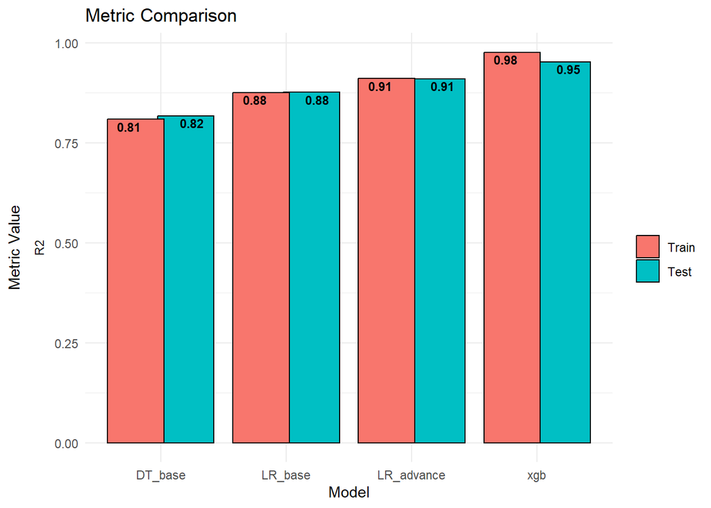

```r
print(r2_metrics)
```

#### 4.2 Plot Actual vs. Predicted Test Results

- Plot the results of the advanced LR and XGboost models vs. actual MWh for 2019

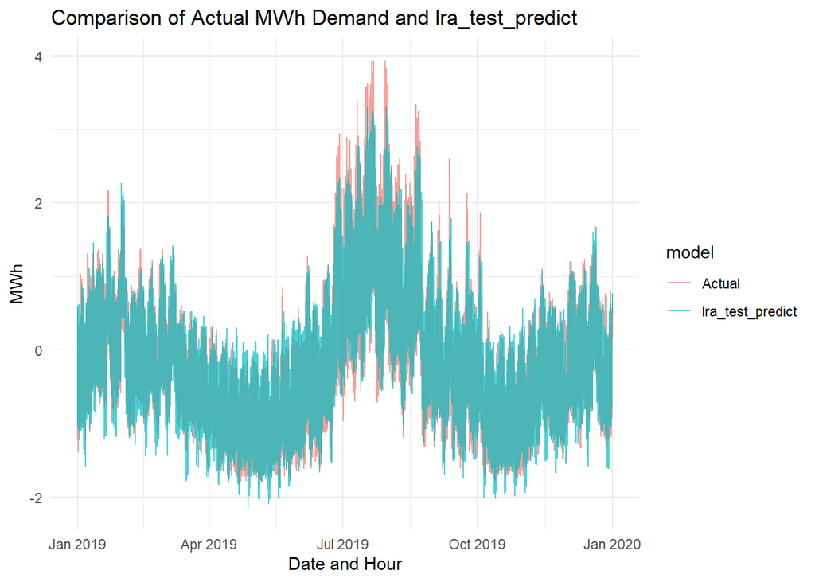

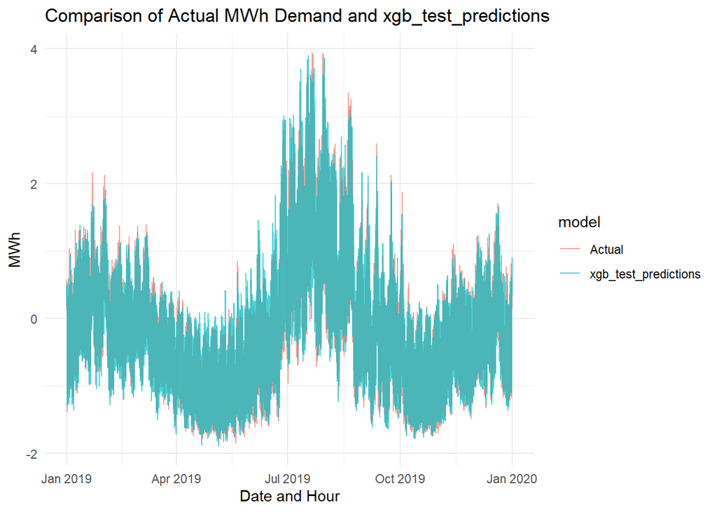

```r
#create plot df
plot <- master %>%
  filter(year %in% c(2019)) %>%
  select(year, month, day, hour)
actual_test <- test$MWh
plot <- cbind(plot, actual_test, lra_test_predict, xgb_test_predictions)
names(plot)[1:4] <- c('Year', 'Month', 'Day', 'Hour')
plot <- add_date(plot)
plot <- plot %>% select(-Year, -Month, -Day, -Hour)
plot <- plot %>% rename(Actual = actual_test)
plot_long <- tidyr::gather(plot, key = "model", value = "MWh", -Date)
model_names <- unique(plot_long$model)
# plot
plots <- lapply(model_names, function(model_name) {
  if (model_name != "Actual") {
    p <- ggplot(data = plot_long[plot_long$model %in% c(model_name, "Actual"), ],
                aes(x = Date, y = MWh, color = model)) +
      geom_line(alpha = 0.7) +
      labs(title = paste("Comparison of Actual MWh Demand and", model_name),
           x = "Date and Hour",
           y = "MWh") +
      theme_minimal()
    return(p)
  }
})
# Print
for (i in 1:length(plots)) {
  if (!is.null(plots[[i]])) {
    print(plots[[i]])
  }
}
```